# Lloyd with true maps

This notebook performs the Lloyd’s algorithm in the Campbell2D case with the true Campbell maps.

## Introduction

```r
load("NewFitting_Charlie_v090821.RData")

source.all("GpOutput2D-main/GpOutput2D/R")
```

```
*** source Campbell2D.R
*** source Fpca2d_OrthoNormalBsplines.R
*** source Fpca2d_utils.R
*** source Fpca2d_Wavelets.R
*** source gp_Fpca2d.R
*** source km_Fpca2d.R
*** source MeanPoe_utils.R
*** source MeanPoe.R
*** source OrthoNormalBsplines2D_utils.R
*** source OrthoNormalBsplines2D.R
*** source predict_Fpca2d.R
*** source predict_utils.R
*** source simulate_Fpca2d.R
*** source utils.R
*** source Wavelet2D.R
```

```r
source("Campbell2D.R")
source("Campbell_utils.R")
```

The performance of the method is evaluated on an analytical test case, called the Campbell2D function. This function has eight inputs (d=8) and a spatial map as output, i.e a function which depends on two inputs $(\textbf{z} = (z_{1},z_{2}))$ corresponding to spatial coordinates.

$$\begin{align*}
h\colon \;\;\;\;\;\;\;\;\;\; [-1,5]^{8} &\longrightarrow \mathbb{L}^{2}([-90,90]^{2}) \\
\textbf{x} = (x_{1},\dots, x_{8}) &\longmapsto h_{\textbf{x}}(\textbf{z}).
\end{align*}$$
where $\textbf{z} = (z_{1}, z_{2}) \in [-90,90]^{2}$, $x_{j} \in [-1,5]$ for $j = 1,\dots,8$ and
$$\begin{align*}
h_{\textbf{x}}(z_{1}, z_{2}) &= x_{1}\exp[-\frac{(0.8z_{1}+0.2z_{2}-10x_{2})^2}{60x_{1}^2}] \\
&+ (x_{2}+x_{4})\exp[\frac{(0.5z_1+0.5z_2)x_{1}}{500}] + x_{5}(x_{3}-2)\exp[-\frac{(0.4z_{1}+0.6z_{2}-20x_{6})^2}{40x_{5}^2}] \\
&+
(x_{6}+x_{8})\exp[\frac{(0.3z_1+0.7z_2)x_{7}}{250}]
\end{align*}$$

As in the coastal case we work in 7 dimensions, we fix don’t consider the 8th dimension of the input : we set $x_{8} = -1$

We will work with Campbell maps 64x64.

```r
dim_map = c(64,64)

z1 = seq(-90,90,l=dim_map[1])
z2 = seq(-90,90,l=dim_map[2])
```

We sample $(\tilde{X}^{(k)})_{k \in \{1,\dots,10^6\}}$ i.i.d of density function $\nu= \nu_{1}\times\dots\times \nu_{7}$ with $\forall i \in \{1,\dots,5\}, \nu_{i} = \mathbb{1}_{[0,1]}$, $\nu_{6} = \frac{1}{10}\sum_{k=1}^{10}\delta_{\frac{1}{10}}$ and $\nu_{7} = \frac{5}{13} \delta_{0} + (\frac{8}{13})\mathbb{1}_{]0,1]}$.

Then we perform a linear transformation of $(\tilde{X}^{(k)})_{k \in \{1,\dots,10^6\}}$ so that $\tilde{X}^{(k)} \in [-1,5]^7$.

We also compute $(\tilde{X}_{phy}^{(k)})_{k \in \{1,\dots,10^6\}}$ that is a linear transformation of $\tilde{X}$ in the support of $f_{X}$, so that we compute the weights $\left(\frac{f_{X}(\tilde{X}^{(k)})}{\nu(\tilde{X}^{(k)})}\right){_{k \in \{1,\dots,10^6\}}}$.

```r
set.seed(1234)
n=10^6
Xsobol = matrix(runif(n =5*n), ncol = 5)
Xsobol = cbind(Xsobol, sample(1:10,size = n, replace = TRUE) / 10)

unif = runif(n)
Xsobol = cbind(Xsobol, (unif <= 8/13)*runif(n))

Xsobol = cbind(Xsobol, rep(-1,n))
Xsobol = transform_X(Xsobol)
```

```r
Xsobol_phy = ((Xsobol + 1)/6)[,1:7]
for(i in 1:5){
  Xsobol_phy[,i] = Xsobol_phy[,i] * (df_bornes[i,2]-df_bornes[i,1]) + df_bornes[i,1]
}
Xsobol_phy[,6] = Xsobol_phy[,6]*10

registerDoParallel(cores = 24)

densite_vec = foreach(it = 1:10, .combine = "c") %dopar% {
  densite_ratio_full_vec(Xsobol_phy[((it-1)*10^5 + 1):(it*10^5),])
}
```

```r
maps_true = lapply(1:1, function(it){
    print(it)
    Campbell2D(Xsobol[((it-1)*10^5+1):(it*10^5),], z1, z2)})
```

```
[1] 1
```

We sample randomly $\Gamma_{0}$

```r
set.seed(709000)
indices = sample(1:10^5, 5)

gamma = lapply(1:5, function(j){maps_true[[1]][,,indices[j]]})
```

## Adapted lloyd algorithm

```r
lloyd_campbell = function(gamma, maps, densite_vec){
  n = dim(maps[[1]])[3]*length(maps) #nb of maps
  card = length(gamma) #nb of prototype maps
    for (i in 1:100){ #budget
      print(i)
      gamma_new <<- list() #Initilize the new prototype maps
      proba_cluster = c()
      numeros = Vectorize(function(it){get_numeros(maps[[it]],gamma)})(1:length(maps)) #Associate each map to its Voronoi cell
      for (j in 1:card){ #for each Voronoi cell
        estim_1 = rep(0, dim_map[1]*dim_map[2]) ## Compute estim_1*n
        for(batch in 1:length(maps)){ ## For each batch of maps_true
          estim_1 = estim_1 + apply(t(matrix(maps[[batch]][,,numeros[,batch] == j],nrow = dim_map[1]*dim_map[2], ncol = sum(numeros[,batch] == j)))*densite_vec[((batch-1)*10^5 + 1):(batch*10^5)][numeros[,batch] == j],2, sum) ## Sum the Y(X)f/nu of the cell
        }
        estim_2 = sum(densite_vec[as.numeric(numeros) == j]) ## Sum the f/nu(X) of the cell
        centroid = estim_1/estim_2 ## Compute the ratio of the two estimators
        proba_cluster = c(proba_cluster, estim_2/n) ## Store the estimated probability mass of the cell

        gamma_new[[j]] <<- matrix(centroid, ncol = ncol(gamma[[j]])) ## store the centroid in gamma_new

      }
      check_fixed_point = 0 #check_fixed_point checks if gamma_new is different the previous gamma
      for (m in 1:card){
        check_fixed_point = check_fixed_point + distance_gamma(gamma_new[[m]], gamma)$dist

      }
      if (check_fixed_point == 0){break} #if they are equal, then break
      water_volume = c()  #we will sort the prototype maps by increasing water volume
      for (k in 1:card){water_volume = c(water_volume, sum(gamma_new[[k]]))}
      for(k in 1:card){gamma[[rank(water_volume)[k]]] = gamma_new[[k]]}
      }
    return(list(gamma = gamma, iterations = i, numeros = numeros, proba = proba_cluster))  # return the optimal gamma, the number of iterations, the cells of each map and the probabilities associated to the cells
}
```

```r
lloyd_res_true = lloyd_campbell(gamma, map_sobol_true, densite_vec)
```

Visualisation of the obtained prototype maps.

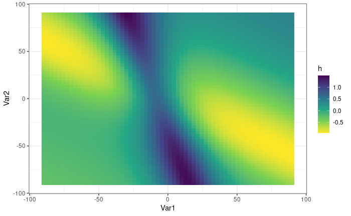

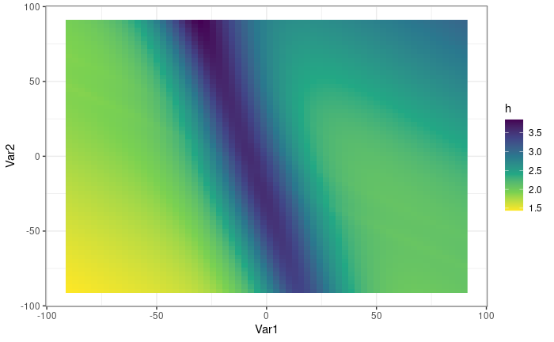

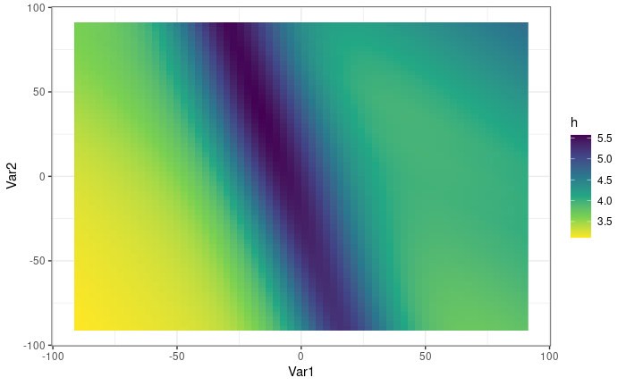

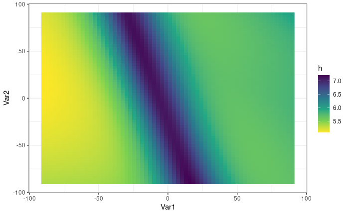

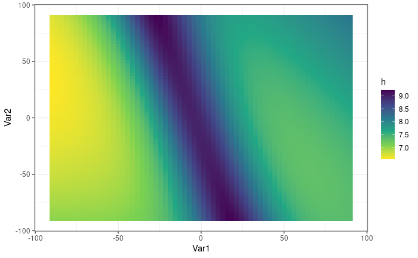

```r
for(i in 1:5){print(plot_map(lloyd_res_true$gamma[[i]]))}
```

```r
rm(maps_true)
save(lloyd_res_true, file = "lloyd_res_true.RData")
```